# Analiza wytwarzania energii w elektrownii słonecznej

#### Wartości parametru statystycznego Morana I parametrów słońca w momencie pomiaru:

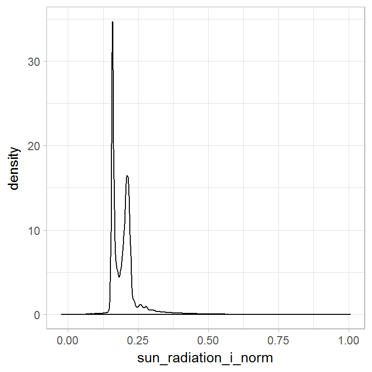

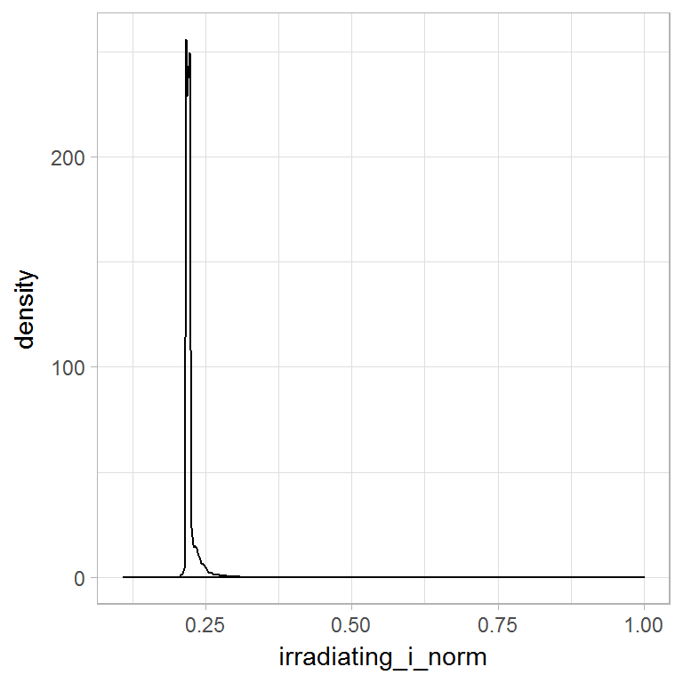

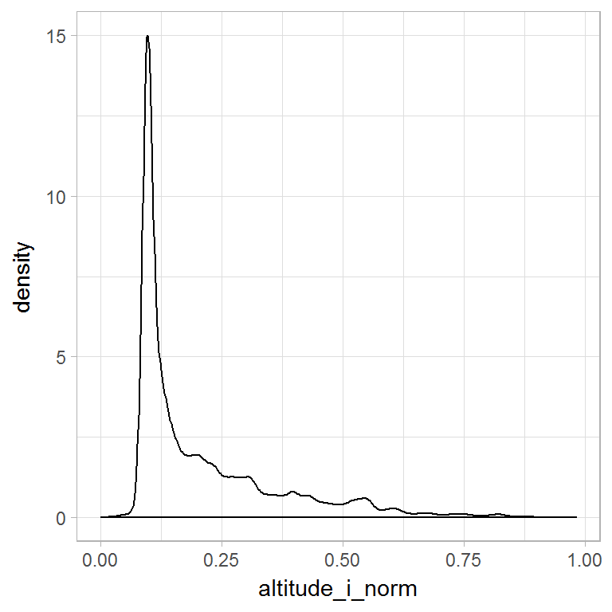

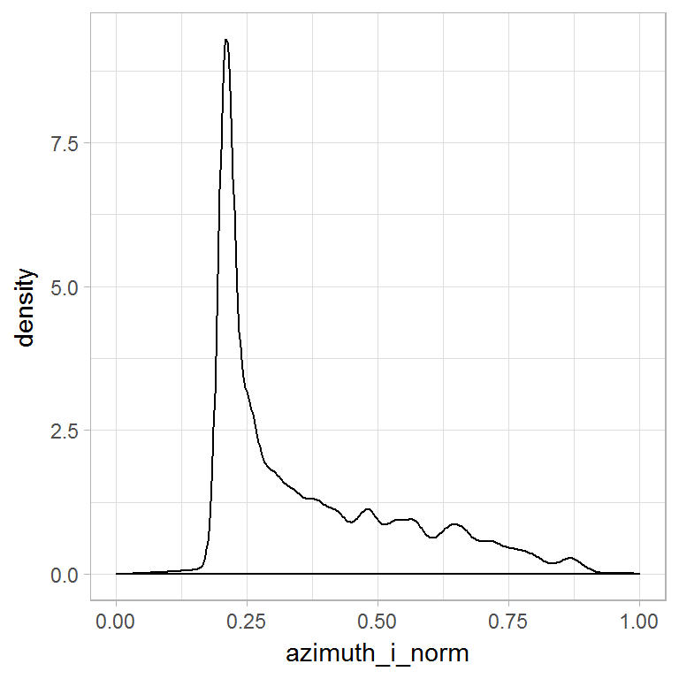

#### Parametry pcnm_norm_X:

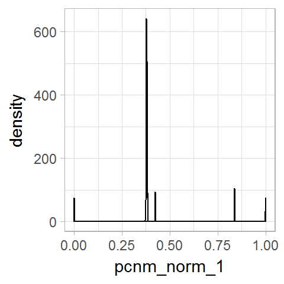

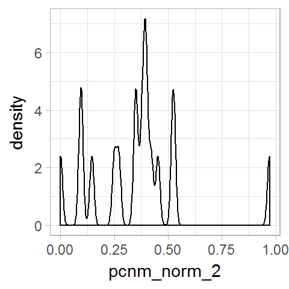

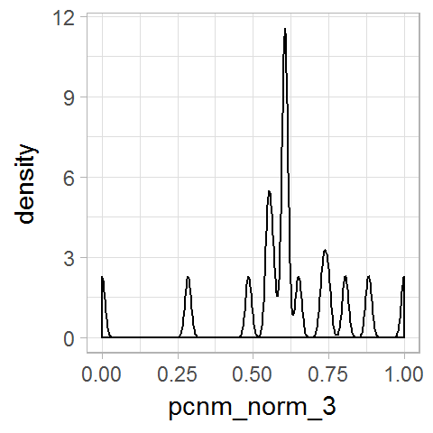

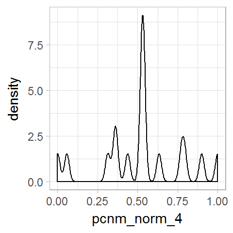

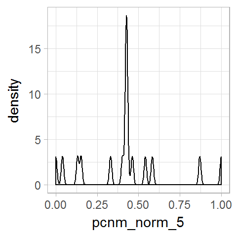

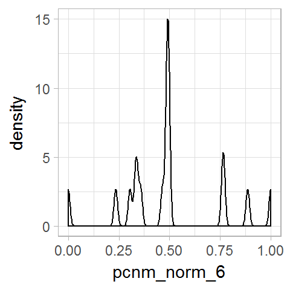

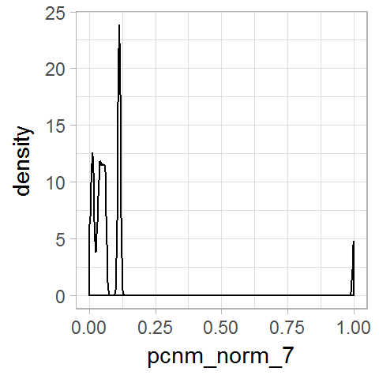

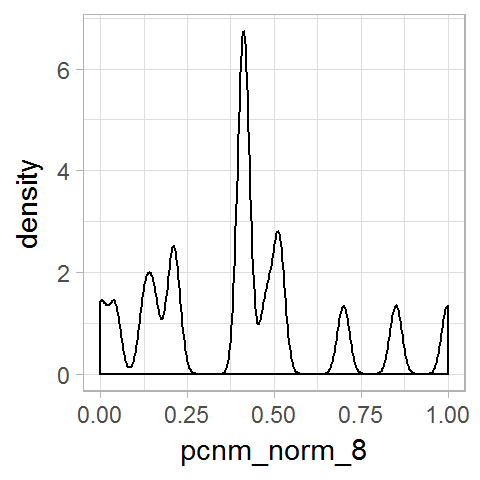

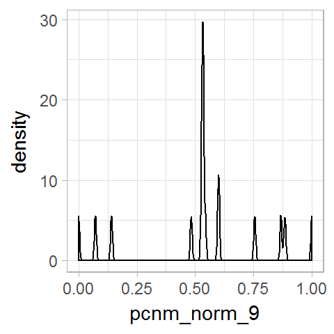

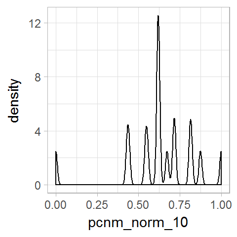

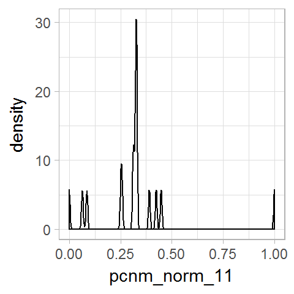

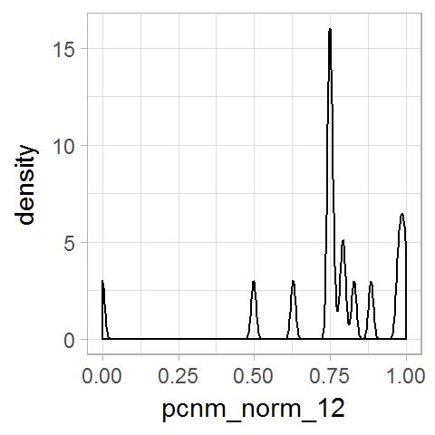

[3 more figures not shown]

#### Wartość wytwarzanej energii:

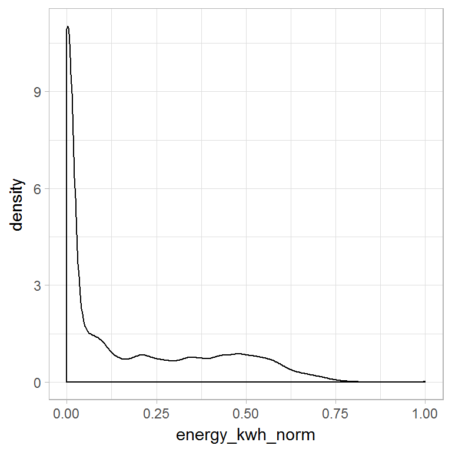

## 9. Wykres obrazujący wytwarzaną energię w czasie w każdej elektrowni

W tym rozdziale stworzone zostały wykresy prezentujący wytwarzaną energię różnych elektrowni w czasie. Wytwarzana elektrownia jest sumowana w danym miesiącu dla danej elektrowni. Podział na cztery wykresy wynika z małej czytelności.

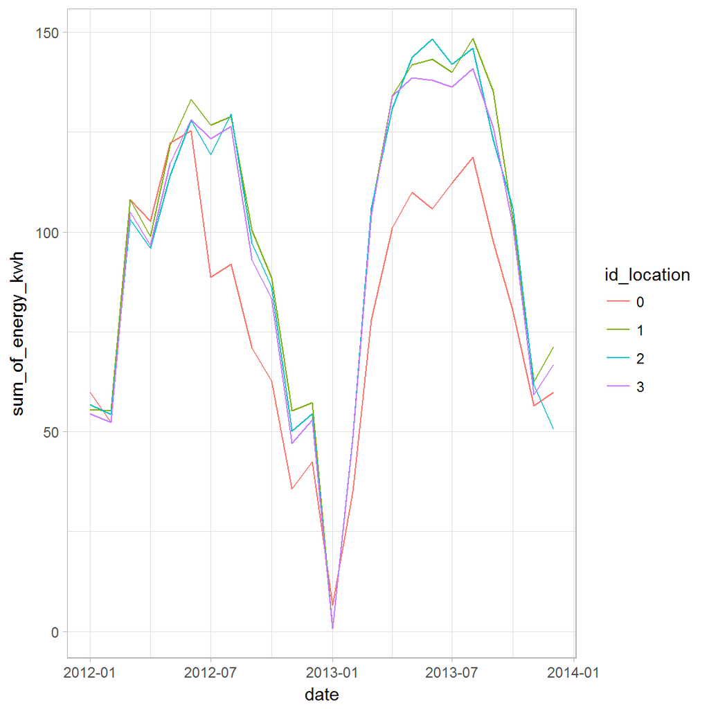

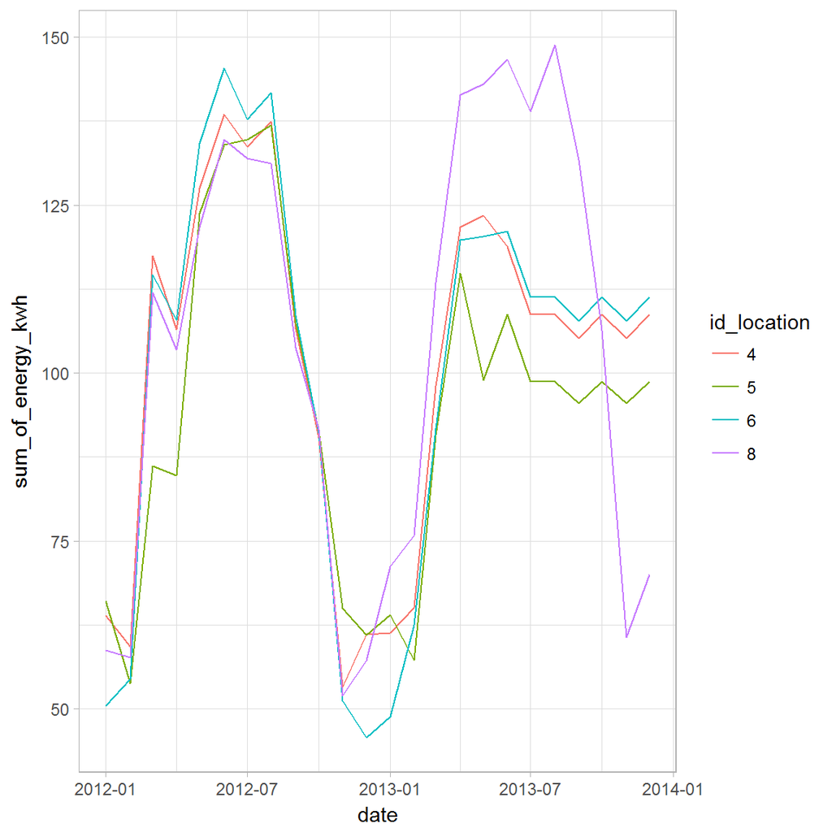

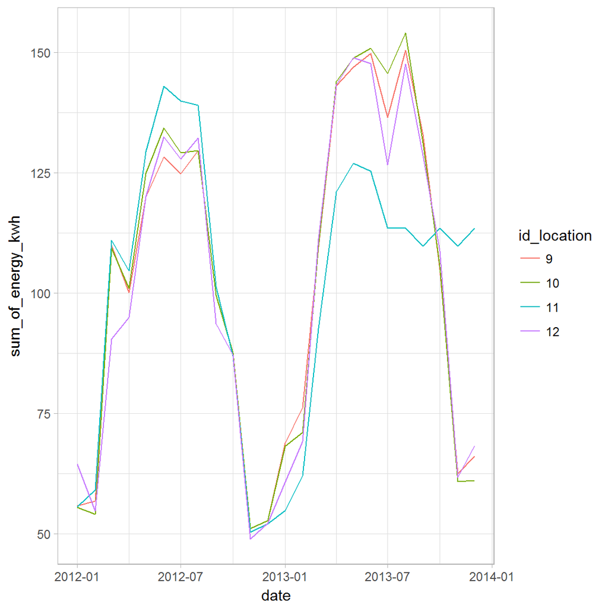

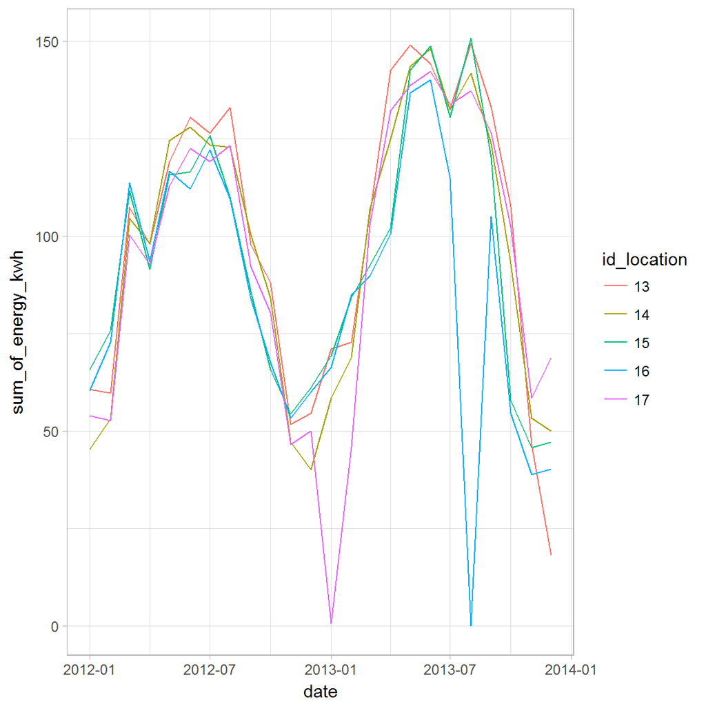

## 10. Korelacje między zmiennymi

### Tabele korelacji między atrybutami w zbiorze danych

Poniżej przedstawione zostały tabele korelacji między atrybutami w zbiorze danych. Dla większej czytelności jedna duża tabela korelacji została podzielona na wiele mnieszych. Kolor niebieski i liczba dodatnia oznacza korelację proporcjonalną, zero oznacza brak korelacji, liczby ujemne oznaczają korelację odwrotną. Do obliczenia współczynnika korelacji użyto funkcji cor().

| attribute | id_location | latitude_norm | longitude_norm | id_brand_norm | id_model_norm | age_in_months_norm | day_of_year_norm | hour_of_day_norm | season_norm | energy_kwh_norm |
| --- | --- | --- | --- | --- | --- | --- | --- | --- | --- | --- |
| id_location | 1.00 | 0.50 | -0.50 | -0.71 | 0.18 | -0.34 | 0.00 | 0.00 | 0.00 | 0.00 |
| latitude_norm | 0.50 | 1.00 | -1.00 | -0.46 | 0.43 | -0.15 | 0.00 | 0.00 | 0.00 | -0.02 |
| longitude_norm | -0.50 | -1.00 | 1.00 | 0.45 | -0.42 | 0.17 | 0.00 | 0.00 | 0.00 | 0.02 |
| id_brand_norm | -0.71 | -0.46 | 0.45 | 1.00 | -0.10 | 0.45 | 0.00 | 0.00 | 0.00 | 0.00 |
| id_model_norm | 0.18 | 0.43 | -0.42 | -0.10 | 1.00 | -0.10 | 0.00 | 0.00 | 0.00 | 0.00 |
| age_in_months_norm | -0.34 | -0.15 | 0.17 | 0.45 | -0.10 | 1.00 | 0.00 | 0.00 | 0.00 | -0.02 |
| day_of_year_norm | 0.00 | 0.00 | 0.00 | 0.00 | 0.00 | 0.00 | 1.00 | 0.00 | -0.06 | -0.01 |
| hour_of_day_norm | 0.00 | 0.00 | 0.00 | 0.00 | 0.00 | 0.00 | 0.00 | 1.00 | 0.00 | -0.08 |
| season_norm | 0.00 | 0.00 | 0.00 | 0.00 | 0.00 | 0.00 | -0.06 | 0.00 | 1.00 | -0.23 |
| energy_kwh_norm | 0.00 | -0.02 | 0.02 | 0.00 | 0.00 | -0.02 | -0.01 | -0.08 | -0.23 | 1.00 |

| attribute | avg_ambient_temperature_norm | pressure_norm | wind_speed_norm | humidity_norm | dew_point_norm | wind_direction_norm | cloud_cover_norm | icon_norm | irradiating_norm | altitude_norm | azimuth_norm | sun_radiation_norm | energy_kwh_norm |
| --- | --- | --- | --- | --- | --- | --- | --- | --- | --- | --- | --- | --- | --- |
| avg_ambient_temperature_norm | 1.00 | 0.10 | 0.05 | -0.50 | 0.32 | -0.29 | -0.02 | 0.01 | 0.24 | 0.78 | 0.62 | 0.24 | 0.20 |
| pressure_norm | 0.10 | 1.00 | 0.18 | -0.19 | 0.14 | 0.10 | -0.08 | -0.01 | 0.10 | 0.11 | 0.05 | 0.10 | 0.07 |
| wind_speed_norm | 0.05 | 0.18 | 1.00 | -0.13 | -0.12 | 0.15 | 0.11 | 0.09 | 0.14 | 0.11 | 0.00 | 0.14 | 0.12 |
| humidity_norm | -0.50 | -0.19 | -0.13 | 1.00 | -0.11 | 0.11 | 0.29 | 0.13 | -0.55 | -0.58 | -0.14 | -0.55 | -0.53 |
| dew_point_norm | 0.32 | 0.14 | -0.12 | -0.11 | 1.00 | -0.14 | -0.04 | -0.09 | 0.14 | 0.24 | 0.04 | 0.15 | 0.09 |
| wind_direction_norm | -0.29 | 0.10 | 0.15 | 0.11 | -0.14 | 1.00 | -0.02 | 0.02 | -0.11 | -0.26 | -0.16 | -0.10 | -0.11 |
| cloud_cover_norm | -0.02 | -0.08 | 0.11 | 0.29 | -0.04 | -0.02 | 1.00 | 0.50 | -0.10 | 0.03 | 0.06 | -0.08 | -0.12 |
| icon_norm | 0.01 | -0.01 | 0.09 | 0.13 | -0.09 | 0.02 | 0.50 | 1.00 | -0.04 | 0.05 | 0.07 | -0.02 | -0.07 |
| irradiating_norm | 0.24 | 0.10 | 0.14 | -0.55 | 0.14 | -0.11 | -0.10 | -0.04 | 1.00 | 0.44 | -0.19 | 0.91 | 0.86 |
| altitude_norm | 0.78 | 0.11 | 0.11 | -0.58 | 0.24 | -0.26 | 0.03 | 0.05 | 0.44 | 1.00 | 0.60 | 0.44 | 0.40 |
| azimuth_norm | 0.62 | 0.05 | 0.00 | -0.14 | 0.04 | -0.16 | 0.06 | 0.07 | -0.19 | 0.60 | 1.00 | -0.18 | -0.18 |
| sun_radiation_norm | 0.24 | 0.10 | 0.14 | -0.55 | 0.15 | -0.10 | -0.08 | -0.02 | 0.91 | 0.44 | -0.18 | 1.00 | 0.85 |
| energy_kwh_norm | 0.20 | 0.07 | 0.12 | -0.53 | 0.09 | -0.11 | -0.12 | -0.07 | 0.86 | 0.40 | -0.18 | 0.85 | 1.00 |

| attribute | avg_ambient_temperature_i_norm | pressure_i_norm | wind_speed_i_norm | humidity_i_norm | dew_point_i_norm | wind_direction_i_norm | cloud_cover_i_norm | irradiating_i_norm | altitude_i_norm | azimuth_i_norm | sun_radiation_i_norm | energy_kwh_norm |
| --- | --- | --- | --- | --- | --- | --- | --- | --- | --- | --- | --- | --- |
| avg_ambient_temperature_i_norm | 1.00 | 0.00 | 0.03 | 0.27 | 0.25 | 0.18 | 0.00 | 0.39 | 0.42 | 0.10 | 0.33 | 0.24 |
| pressure_i_norm | 0.00 | 1.00 | 0.00 | 0.02 | 0.00 | -0.01 | 0.00 | 0.00 | 0.15 | 0.08 | 0.02 | -0.03 |
| wind_speed_i_norm | 0.03 | 0.00 | 1.00 | 0.04 | 0.02 | 0.04 | 0.05 | 0.04 | 0.05 | 0.08 | 0.05 | -0.02 |
| humidity_i_norm | 0.27 | 0.02 | 0.04 | 1.00 | 0.05 | 0.09 | 0.06 | 0.22 | 0.23 | 0.04 | 0.22 | 0.12 |
| dew_point_i_norm | 0.25 | 0.00 | 0.02 | 0.05 | 1.00 | 0.07 | 0.01 | 0.09 | 0.11 | 0.14 | 0.10 | 0.00 |
| wind_direction_i_norm | 0.18 | -0.01 | 0.04 | 0.09 | 0.07 | 1.00 | 0.02 | 0.12 | 0.08 | -0.02 | 0.10 | 0.11 |
| cloud_cover_i_norm | 0.00 | 0.00 | 0.05 | 0.06 | 0.01 | 0.02 | 1.00 | 0.01 | 0.05 | 0.09 | 0.04 | -0.09 |
| irradiating_i_norm | 0.39 | 0.00 | 0.04 | 0.22 | 0.09 | 0.12 | 0.01 | 1.00 | 0.10 | -0.07 | 0.71 | 0.40 |
| altitude_i_norm | 0.42 | 0.15 | 0.05 | 0.23 | 0.11 | 0.08 | 0.05 | 0.10 | 1.00 | 0.21 | 0.16 | -0.08 |
| azimuth_i_norm | 0.10 | 0.08 | 0.08 | 0.04 | 0.14 | -0.02 | 0.09 | -0.07 | 0.21 | 1.00 | 0.14 | -0.49 |
| sun_radiation_i_norm | 0.33 | 0.02 | 0.05 | 0.22 | 0.10 | 0.10 | 0.04 | 0.71 | 0.16 | 0.14 | 1.00 | 0.24 |
| energy_kwh_norm | 0.24 | -0.03 | -0.02 | 0.12 | 0.00 | 0.11 | -0.09 | 0.40 | -0.08 | -0.49 | 0.24 | 1.00 |

| attribute | pcnm_norm_1 | pcnm_norm_2 | pcnm_norm_3 | pcnm_norm_4 | pcnm_norm_5 | pcnm_norm_6 | pcnm_norm_7 | pcnm_norm_8 | pcnm_norm_9 | pcnm_norm_10 | pcnm_norm_11 | pcnm_norm_12 | pcnm_norm_13 | pcnm_norm_14 | pcnm_norm_15 | energy_kwh_norm |
| --- | --- | --- | --- | --- | --- | --- | --- | --- | --- | --- | --- | --- | --- | --- | --- | --- |
| pcnm_norm_1 | 1.00 | 0.03 | 0.00 | 0.01 | 0.01 | 0.00 | 0.00 | 0.01 | 0.00 | -0.01 | 0.00 | -0.01 | -0.03 | -0.02 | 0.00 | 0.01 |
| pcnm_norm_2 | 0.03 | 1.00 | -0.01 | -0.14 | -0.13 | 0.01 | 0.00 | -0.10 | 0.05 | 0.12 | -0.05 | 0.12 | 0.55 | 0.26 | -0.04 | 0.01 |
| pcnm_norm_3 | 0.00 | -0.01 | 1.00 | 0.00 | 0.00 | 0.00 | 0.00 | 0.00 | 0.00 | 0.00 | 0.00 | 0.00 | 0.01 | 0.01 | 0.00 | 0.00 |
| pcnm_norm_4 | 0.01 | -0.14 | 0.00 | 1.00 | -0.04 | 0.00 | 0.00 | -0.03 | 0.02 | 0.03 | -0.01 | 0.03 | 0.15 | 0.07 | -0.01 | -0.01 |
| pcnm_norm_5 | 0.01 | -0.13 | 0.00 | -0.04 | 1.00 | 0.00 | 0.00 | -0.03 | 0.01 | 0.03 | -0.01 | 0.03 | 0.14 | 0.07 | -0.01 | -0.01 |
| pcnm_norm_6 | 0.00 | 0.01 | 0.00 | 0.00 | 0.00 | 1.00 | 0.00 | 0.00 | 0.00 | 0.00 | 0.00 | 0.00 | -0.01 | -0.01 | 0.00 | 0.01 |
| pcnm_norm_7 | 0.00 | 0.00 | 0.00 | 0.00 | 0.00 | 0.00 | 1.00 | 0.00 | 0.00 | 0.00 | 0.00 | 0.00 | 0.00 | 0.00 | 0.00 | -0.04 |
| pcnm_norm_8 | 0.01 | -0.10 | 0.00 | -0.03 | -0.03 | 0.00 | 0.00 | 1.00 | 0.01 | 0.03 | -0.01 | 0.02 | 0.11 | 0.05 | -0.01 | 0.01 |
| pcnm_norm_9 | 0.00 | 0.05 | 0.00 | 0.02 | 0.01 | 0.00 | 0.00 | 0.01 | 1.00 | -0.01 | 0.00 | -0.01 | -0.06 | -0.03 | 0.00 | 0.01 |
| pcnm_norm_10 | -0.01 | 0.12 | 0.00 | 0.03 | 0.03 | 0.00 | 0.00 | 0.03 | -0.01 | 1.00 | 0.01 | -0.03 | -0.13 | -0.06 | 0.01 | -0.01 |
| pcnm_norm_11 | 0.00 | -0.05 | 0.00 | -0.01 | -0.01 | 0.00 | 0.00 | -0.01 | 0.00 | 0.01 | 1.00 | 0.01 | 0.05 | 0.02 | 0.00 | 0.00 |
| pcnm_norm_12 | -0.01 | 0.12 | 0.00 | 0.03 | 0.03 | 0.00 | 0.00 | 0.02 | -0.01 | -0.03 | 0.01 | 1.00 | -0.13 | -0.06 | 0.01 | -0.01 |
| pcnm_norm_13 | -0.03 | 0.55 | 0.01 | 0.15 | 0.14 | -0.01 | 0.00 | 0.11 | -0.06 | -0.13 | 0.05 | -0.13 | 1.00 | -0.28 | 0.04 | 0.01 |
| pcnm_norm_14 | -0.02 | 0.26 | 0.01 | 0.07 | 0.07 | -0.01 | 0.00 | 0.05 | -0.03 | -0.06 | 0.02 | -0.06 | -0.28 | 1.00 | 0.02 | 0.00 |
| pcnm_norm_15 | 0.00 | -0.04 | 0.00 | -0.01 | -0.01 | 0.00 | 0.00 | -0.01 | 0.00 | 0.01 | 0.00 | 0.01 | 0.04 | 0.02 | 1.00 | 0.01 |
| energy_kwh_norm | 0.01 | 0.01 | 0.00 | -0.01 | -0.01 | 0.01 | -0.04 | 0.01 | 0.01 | -0.01 | 0.00 | -0.01 | 0.01 | 0.00 | 0.01 | 1.00 |

| attribute | avg_ambient_temperature_norm | pressure_norm | wind_speed_norm | humidity_norm | dew_point_norm | wind_direction_norm | cloud_cover_norm | icon_norm | irradiating_norm | altitude_norm | azimuth_norm | sun_radiation_norm | energy_kwh_norm |
| --- | --- | --- | --- | --- | --- | --- | --- | --- | --- | --- | --- | --- | --- |
| id_location | -0.03 | -0.44 | -0.13 | 0.07 | -0.07 | -0.07 | 0.04 | -0.01 | -0.07 | 0.00 | 0.02 | -0.07 | 0.00 |
| latitude_norm | -0.06 | -0.89 | -0.22 | 0.15 | -0.11 | -0.13 | 0.09 | -0.01 | -0.05 | 0.00 | 0.03 | -0.07 | -0.02 |
| longitude_norm | 0.06 | 0.89 | 0.21 | -0.15 | 0.11 | 0.12 | -0.10 | 0.01 | 0.05 | 0.00 | -0.03 | 0.06 | 0.02 |
| id_brand_norm | 0.02 | 0.41 | 0.10 | -0.06 | 0.04 | 0.07 | -0.04 | 0.00 | 0.04 | 0.00 | -0.01 | 0.05 | 0.00 |
| id_model_norm | -0.03 | -0.37 | -0.09 | 0.07 | -0.06 | -0.06 | 0.03 | -0.02 | -0.02 | -0.01 | 0.01 | -0.02 | 0.00 |
| age_in_months_norm | -0.01 | 0.16 | 0.03 | 0.03 | -0.01 | 0.00 | -0.03 | -0.07 | -0.03 | -0.03 | 0.00 | -0.05 | -0.02 |
| day_of_year_norm | 0.15 | 0.00 | -0.14 | 0.00 | 0.43 | -0.03 | 0.03 | -0.14 | -0.04 | -0.01 | 0.02 | -0.03 | -0.01 |
| hour_of_day_norm | 0.67 | 0.09 | 0.03 | -0.21 | 0.06 | -0.16 | 0.06 | 0.07 | -0.07 | 0.67 | 0.96 | -0.07 | -0.08 |
| season_norm | -0.32 | -0.06 | 0.05 | 0.46 | -0.58 | 0.10 | 0.26 | 0.18 | -0.30 | -0.33 | 0.04 | -0.31 | -0.23 |
| energy_kwh_norm | 0.20 | 0.07 | 0.12 | -0.53 | 0.09 | -0.11 | -0.12 | -0.07 | 0.86 | 0.40 | -0.18 | 0.85 | 1.00 |

| attribute | avg_ambient_temperature_i_norm | pressure_i_norm | wind_speed_i_norm | humidity_i_norm | dew_point_i_norm | wind_direction_i_norm | cloud_cover_i_norm | irradiating_i_norm | altitude_i_norm | azimuth_i_norm | sun_radiation_i_norm | energy_kwh_norm |
| --- | --- | --- | --- | --- | --- | --- | --- | --- | --- | --- | --- | --- |
| id_location | 0.02 | 0.00 | 0.02 | 0.01 | 0.01 | 0.03 | 0.01 | -0.05 | 0.02 | 0.02 | -0.01 | 0.00 |
| latitude_norm | 0.08 | 0.00 | 0.06 | 0.04 | 0.05 | 0.06 | 0.04 | 0.01 | 0.08 | 0.10 | 0.03 | -0.02 |
| longitude_norm | -0.06 | 0.00 | -0.05 | -0.03 | -0.05 | -0.06 | -0.04 | 0.00 | -0.07 | -0.09 | -0.02 | 0.02 |
| id_brand_norm | -0.06 | 0.00 | -0.03 | -0.03 | -0.04 | -0.03 | -0.03 | 0.00 | -0.06 | -0.07 | -0.03 | 0.00 |
| id_model_norm | 0.03 | 0.00 | 0.03 | 0.02 | 0.02 | 0.03 | 0.03 | 0.00 | 0.04 | 0.04 | 0.03 | 0.00 |
| age_in_months_norm | 0.08 | 0.01 | 0.04 | 0.06 | 0.05 | 0.04 | 0.06 | 0.09 | 0.09 | 0.10 | 0.08 | -0.02 |
| day_of_year_norm | -0.08 | 0.00 | -0.03 | -0.05 | -0.08 | -0.05 | 0.01 | -0.12 | -0.06 | -0.11 | -0.11 | -0.01 |
| hour_of_day_norm | 0.11 | -0.09 | 0.00 | 0.01 | 0.03 | 0.07 | -0.05 | -0.02 | -0.25 | 0.09 | 0.00 | -0.08 |
| season_norm | -0.38 | 0.05 | 0.03 | -0.03 | -0.10 | -0.07 | 0.06 | -0.11 | 0.00 | -0.13 | -0.09 | -0.23 |
| energy_kwh_norm | 0.24 | -0.03 | -0.02 | 0.12 | 0.00 | 0.11 | -0.09 | 0.40 | -0.08 | -0.49 | 0.24 | 1.00 |

| attribute | pcnm_norm_1 | pcnm_norm_2 | pcnm_norm_3 | pcnm_norm_4 | pcnm_norm_5 | pcnm_norm_6 | pcnm_norm_7 | pcnm_norm_8 | pcnm_norm_9 | pcnm_norm_10 | pcnm_norm_11 | pcnm_norm_12 | pcnm_norm_13 | pcnm_norm_14 | pcnm_norm_15 | energy_kwh_norm |
| --- | --- | --- | --- | --- | --- | --- | --- | --- | --- | --- | --- | --- | --- | --- | --- | --- |
| id_location | 0.12 | 0.32 | -0.02 | -0.38 | 0.30 | -0.34 | -0.33 | -0.26 | 0.04 | -0.25 | 0.23 | 0.10 | 0.12 | 0.11 | -0.15 | 0.00 |
| latitude_norm | 0.00 | 0.07 | 0.00 | 0.01 | 0.01 | -0.01 | -0.01 | -0.01 | -0.01 | -0.01 | 0.00 | 0.00 | -0.06 | -0.03 | -0.01 | -0.02 |
| longitude_norm | -0.04 | -0.09 | 0.00 | -0.01 | -0.01 | 0.00 | 0.00 | -0.01 | 0.00 | 0.01 | 0.00 | 0.01 | 0.04 | 0.02 | 0.03 | 0.02 |
| id_brand_norm | 0.12 | -0.12 | 0.23 | 0.50 | -0.13 | 0.28 | 0.35 | -0.11 | -0.04 | 0.31 | 0.02 | 0.04 | 0.18 | -0.34 | -0.12 | 0.00 |
| id_model_norm | 0.00 | -0.01 | -0.29 | 0.14 | -0.32 | -0.19 | -0.33 | -0.04 | -0.09 | -0.04 | -0.27 | 0.20 | 0.19 | -0.61 | -0.06 | 0.00 |
| age_in_months_norm | -0.06 | -0.22 | 0.39 | 0.51 | 0.18 | -0.33 | 0.21 | -0.14 | -0.13 | 0.30 | -0.39 | 0.11 | -0.12 | 0.08 | 0.05 | -0.02 |
| day_of_year_norm | 0.00 | 0.00 | 0.00 | 0.00 | 0.00 | 0.00 | 0.00 | 0.00 | 0.00 | 0.00 | 0.00 | 0.00 | 0.00 | 0.00 | 0.00 | -0.01 |
| hour_of_day_norm | 0.00 | 0.00 | 0.00 | 0.00 | 0.00 | 0.00 | 0.00 | 0.00 | 0.00 | 0.00 | 0.00 | 0.00 | 0.00 | 0.00 | 0.00 | -0.08 |
| season_norm | 0.00 | 0.00 | 0.00 | 0.00 | 0.00 | 0.00 | 0.00 | 0.00 | 0.00 | 0.00 | 0.00 | 0.00 | 0.00 | 0.00 | 0.00 | -0.23 |
| energy_kwh_norm | 0.01 | 0.01 | 0.00 | -0.01 | -0.01 | 0.01 | -0.04 | 0.01 | 0.01 | -0.01 | 0.00 | -0.01 | 0.01 | 0.00 | 0.01 | 1.00 |

| attribute | avg_ambient_temperature_i_norm | pressure_i_norm | wind_speed_i_norm | humidity_i_norm | dew_point_i_norm | wind_direction_i_norm | cloud_cover_i_norm | irradiating_i_norm | altitude_i_norm | azimuth_i_norm | sun_radiation_i_norm | energy_kwh_norm |
| --- | --- | --- | --- | --- | --- | --- | --- | --- | --- | --- | --- | --- |
| avg_ambient_temperature_norm | 0.43 | -0.05 | -0.03 | 0.07 | 0.05 | 0.12 | -0.09 | 0.09 | 0.03 | -0.09 | 0.06 | 0.20 |
| pressure_norm | -0.03 | -0.13 | -0.04 | -0.02 | -0.03 | -0.04 | -0.03 | 0.02 | -0.16 | -0.13 | -0.01 | 0.07 |
| wind_speed_norm | 0.02 | 0.00 | 0.20 | 0.01 | 0.00 | 0.03 | -0.01 | 0.07 | 0.01 | -0.14 | 0.02 | 0.12 |
| humidity_norm | -0.38 | 0.05 | 0.03 | -0.18 | -0.04 | -0.12 | 0.13 | -0.23 | 0.01 | 0.20 | -0.13 | -0.53 |
| dew_point_norm | 0.19 | -0.04 | -0.04 | -0.10 | 0.10 | 0.01 | -0.03 | -0.03 | -0.08 | 0.01 | -0.03 | 0.09 |
| wind_direction_norm | -0.21 | 0.01 | 0.00 | -0.07 | -0.04 | -0.25 | 0.01 | -0.08 | -0.10 | 0.06 | -0.06 | -0.11 |
| cloud_cover_norm | -0.14 | -0.02 | 0.02 | -0.06 | -0.06 | -0.02 | 0.22 | -0.10 | -0.06 | -0.11 | -0.09 | -0.12 |
| icon_norm | -0.07 | 0.00 | -0.01 | -0.05 | -0.02 | -0.02 | -0.15 | -0.05 | 0.02 | -0.04 | -0.03 | -0.07 |
| irradiating_norm | 0.33 | -0.03 | -0.02 | 0.13 | 0.03 | 0.12 | -0.09 | 0.50 | -0.05 | -0.48 | 0.28 | 0.86 |
| altitude_norm | 0.37 | -0.10 | -0.02 | 0.07 | 0.05 | 0.15 | -0.09 | 0.14 | -0.12 | -0.27 | 0.05 | 0.40 |
| azimuth_norm | 0.09 | -0.08 | 0.00 | 0.00 | 0.03 | 0.05 | -0.04 | -0.07 | -0.21 | 0.13 | -0.05 | -0.18 |
| sun_radiation_norm | 0.29 | -0.04 | -0.02 | 0.11 | 0.02 | 0.12 | -0.08 | 0.41 | -0.06 | -0.47 | 0.34 | 0.85 |
| energy_kwh_norm | 0.24 | -0.03 | -0.02 | 0.12 | 0.00 | 0.11 | -0.09 | 0.40 | -0.08 | -0.49 | 0.24 | 1.00 |

| attribute | pcnm_norm_1 | pcnm_norm_2 | pcnm_norm_3 | pcnm_norm_4 | pcnm_norm_5 | pcnm_norm_6 | pcnm_norm_7 | pcnm_norm_8 | pcnm_norm_9 | pcnm_norm_10 | pcnm_norm_11 | pcnm_norm_12 | pcnm_norm_13 | pcnm_norm_14 | pcnm_norm_15 | energy_kwh_norm |
| --- | --- | --- | --- | --- | --- | --- | --- | --- | --- | --- | --- | --- | --- | --- | --- | --- |
| avg_ambient_temperature_norm | -0.02 | -0.01 | -0.01 | 0.00 | 0.00 | 0.00 | -0.01 | -0.01 | 0.01 | 0.00 | 0.02 | 0.01 | -0.01 | 0.00 | 0.02 | 0.20 |
| pressure_norm | -0.03 | -0.06 | 0.00 | -0.02 | -0.01 | 0.00 | 0.00 | -0.01 | 0.01 | 0.01 | 0.00 | 0.01 | 0.06 | 0.03 | 0.03 | 0.07 |
| wind_speed_norm | 0.00 | -0.04 | -0.01 | 0.01 | 0.02 | 0.00 | 0.01 | 0.01 | 0.00 | 0.00 | -0.02 | -0.03 | 0.01 | 0.00 | 0.01 | 0.12 |
| humidity_norm | 0.00 | 0.01 | 0.01 | 0.02 | 0.01 | -0.03 | 0.02 | -0.02 | -0.02 | -0.01 | -0.05 | -0.02 | 0.01 | 0.00 | 0.00 | -0.53 |
| dew_point_norm | -0.05 | -0.01 | -0.01 | 0.00 | -0.01 | 0.02 | -0.01 | -0.01 | 0.02 | 0.02 | 0.03 | 0.01 | -0.01 | 0.00 | 0.05 | 0.09 |
| wind_direction_norm | 0.04 | -0.03 | 0.00 | 0.00 | 0.00 | 0.01 | 0.00 | 0.02 | 0.00 | 0.00 | 0.02 | 0.00 | -0.01 | 0.00 | -0.02 | -0.11 |
| cloud_cover_norm | 0.00 | 0.00 | 0.00 | 0.00 | 0.01 | 0.01 | 0.00 | 0.02 | 0.01 | 0.00 | 0.01 | -0.01 | -0.01 | -0.01 | -0.01 | -0.12 |
| icon_norm | 0.01 | -0.02 | -0.01 | -0.02 | 0.00 | 0.03 | -0.02 | 0.04 | 0.01 | 0.03 | 0.08 | 0.01 | -0.02 | -0.01 | -0.01 | -0.07 |
| irradiating_norm | 0.01 | 0.01 | -0.02 | 0.01 | -0.05 | 0.05 | 0.00 | 0.02 | 0.02 | 0.02 | 0.01 | -0.01 | 0.00 | 0.00 | 0.02 | 0.86 |
| altitude_norm | -0.01 | -0.02 | -0.01 | 0.00 | 0.00 | 0.02 | -0.01 | 0.01 | 0.02 | 0.01 | 0.04 | 0.01 | -0.02 | 0.00 | 0.01 | 0.40 |
| azimuth_norm | 0.00 | 0.01 | 0.00 | 0.00 | 0.00 | 0.00 | 0.00 | 0.00 | 0.00 | 0.00 | -0.01 | 0.00 | 0.00 | 0.00 | 0.00 | -0.18 |
| sun_radiation_norm | 0.00 | 0.00 | -0.03 | 0.00 | -0.05 | 0.05 | 0.00 | 0.02 | 0.03 | 0.01 | 0.04 | -0.01 | 0.00 | -0.02 | 0.02 | 0.85 |
| energy_kwh_norm | 0.01 | 0.01 | 0.00 | -0.01 | -0.01 | 0.01 | -0.04 | 0.01 | 0.01 | -0.01 | 0.00 | -0.01 | 0.01 | 0.00 | 0.01 | 1.00 |

| attribute | pcnm_norm_1 | pcnm_norm_2 | pcnm_norm_3 | pcnm_norm_4 | pcnm_norm_5 | pcnm_norm_6 | pcnm_norm_7 | pcnm_norm_8 | pcnm_norm_9 | pcnm_norm_10 | pcnm_norm_11 | pcnm_norm_12 | pcnm_norm_13 | pcnm_norm_14 | pcnm_norm_15 | energy_kwh_norm |
| --- | --- | --- | --- | --- | --- | --- | --- | --- | --- | --- | --- | --- | --- | --- | --- | --- |
| avg_ambient_temperature_i_norm | -0.14 | -0.01 | -0.05 | 0.12 | 0.06 | -0.08 | 0.01 | 0.08 | -0.05 | -0.06 | 0.02 | -0.06 | 0.15 | 0.04 | 0.15 | 0.24 |
| pressure_i_norm | -0.01 | 0.00 | 0.00 | 0.01 | 0.00 | -0.01 | 0.00 | 0.00 | -0.01 | -0.01 | -0.01 | 0.00 | 0.01 | 0.00 | 0.01 | -0.03 |
| wind_speed_i_norm | -0.05 | 0.00 | -0.01 | 0.04 | 0.02 | -0.04 | 0.01 | 0.02 | -0.03 | -0.03 | -0.01 | -0.02 | 0.05 | 0.01 | 0.06 | -0.02 |
| humidity_i_norm | -0.09 | 0.02 | -0.01 | 0.07 | 0.01 | -0.06 | 0.02 | 0.03 | -0.04 | -0.04 | 0.01 | -0.02 | 0.10 | 0.04 | 0.09 | 0.12 |
| dew_point_i_norm | -0.07 | -0.01 | -0.02 | 0.06 | 0.04 | -0.04 | 0.01 | 0.03 | -0.02 | -0.03 | -0.01 | -0.03 | 0.07 | 0.02 | 0.07 | 0.00 |
| wind_direction_i_norm | -0.04 | 0.01 | 0.01 | 0.04 | 0.00 | -0.05 | 0.01 | 0.01 | -0.03 | -0.02 | 0.00 | -0.01 | 0.04 | 0.02 | 0.05 | 0.11 |
| cloud_cover_i_norm | -0.05 | 0.00 | 0.00 | 0.04 | 0.02 | -0.04 | 0.02 | 0.01 | -0.04 | -0.04 | -0.03 | -0.02 | 0.05 | 0.02 | 0.07 | -0.09 |
| irradiating_i_norm | -0.10 | 0.00 | -0.03 | 0.08 | 0.02 | -0.05 | 0.05 | 0.06 | -0.05 | -0.03 | -0.03 | -0.03 | 0.09 | 0.05 | 0.10 | 0.40 |
| altitude_i_norm | -0.13 | 0.00 | -0.03 | 0.10 | 0.05 | -0.08 | 0.02 | 0.06 | -0.05 | -0.06 | 0.00 | -0.05 | 0.14 | 0.04 | 0.15 | -0.08 |
| azimuth_i_norm | -0.15 | -0.01 | -0.05 | 0.13 | 0.06 | -0.09 | 0.02 | 0.07 | -0.05 | -0.07 | 0.01 | -0.06 | 0.17 | 0.04 | 0.17 | -0.49 |
| sun_radiation_i_norm | -0.13 | 0.01 | -0.05 | 0.11 | 0.04 | -0.07 | 0.02 | 0.07 | -0.05 | -0.05 | 0.00 | -0.05 | 0.16 | 0.04 | 0.15 | 0.24 |
| energy_kwh_norm | 0.01 | 0.01 | 0.00 | -0.01 | -0.01 | 0.01 | -0.04 | 0.01 | 0.01 | -0.01 | 0.00 | -0.01 | 0.01 | 0.00 | 0.01 | 1.00 |

### Wykresy korelacji atrybutów z energy_kwh_norm:

Poniżej zaprezentowane zostały wykresy ilustrujące energy_kwh_norm w zależności od atrybutów, które są najbardziej skorelowane. Pole energy_kwh_norm jest atrybutem najważniejszym, którego wartość będziemy próbowali przewidzieć w dalszej części raportu. Największe korelacje z wartością wytwarzanej energii można było zaobserwować dla pomiarów dotyczących słońca oraz ich parametrów statystycznych Morana I oraz niektórych pomiarów dotyczących pogody.

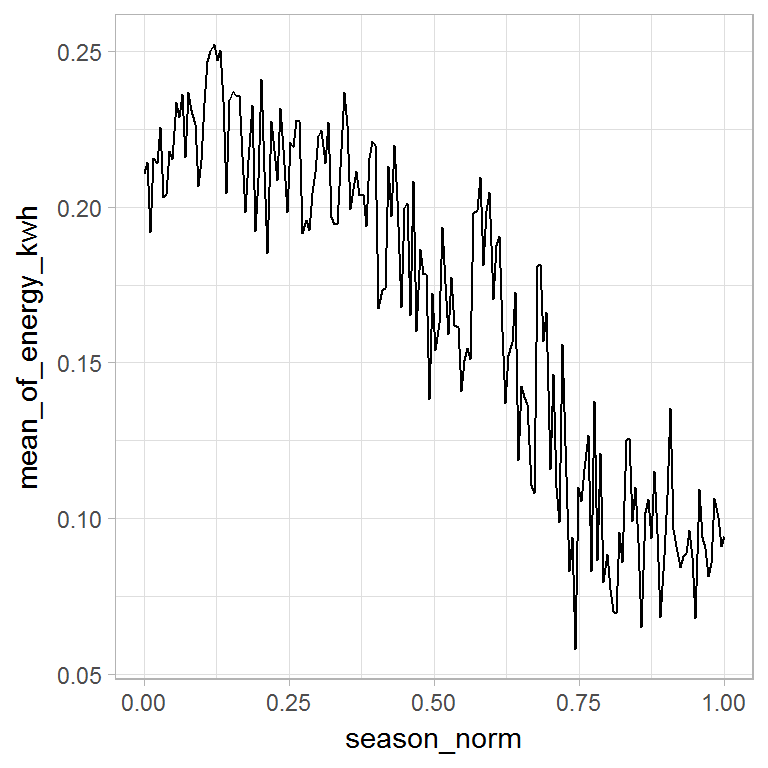

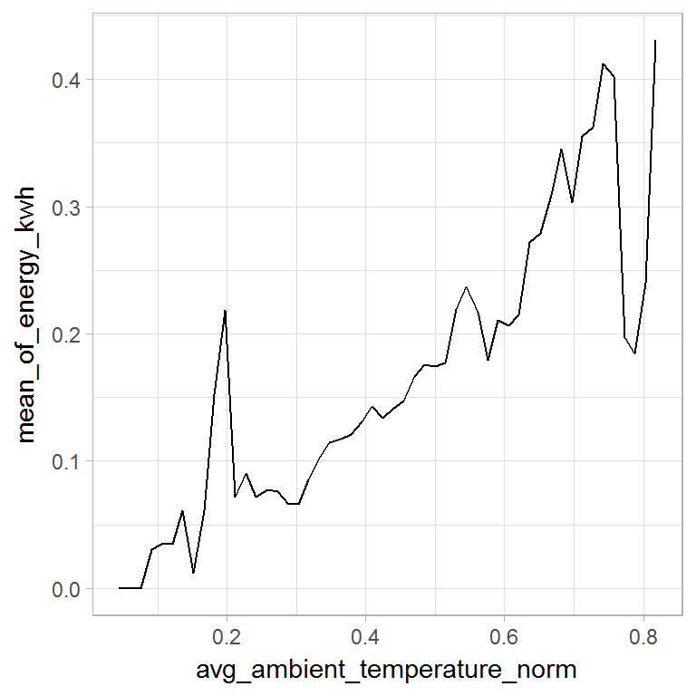

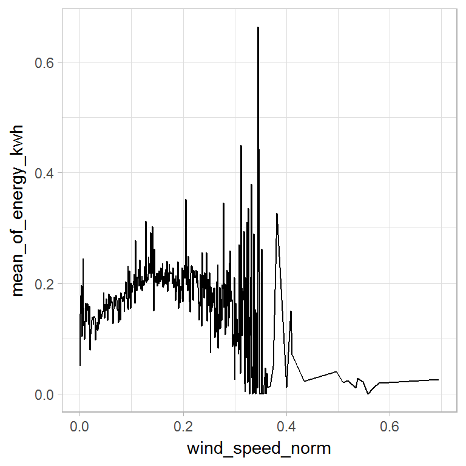

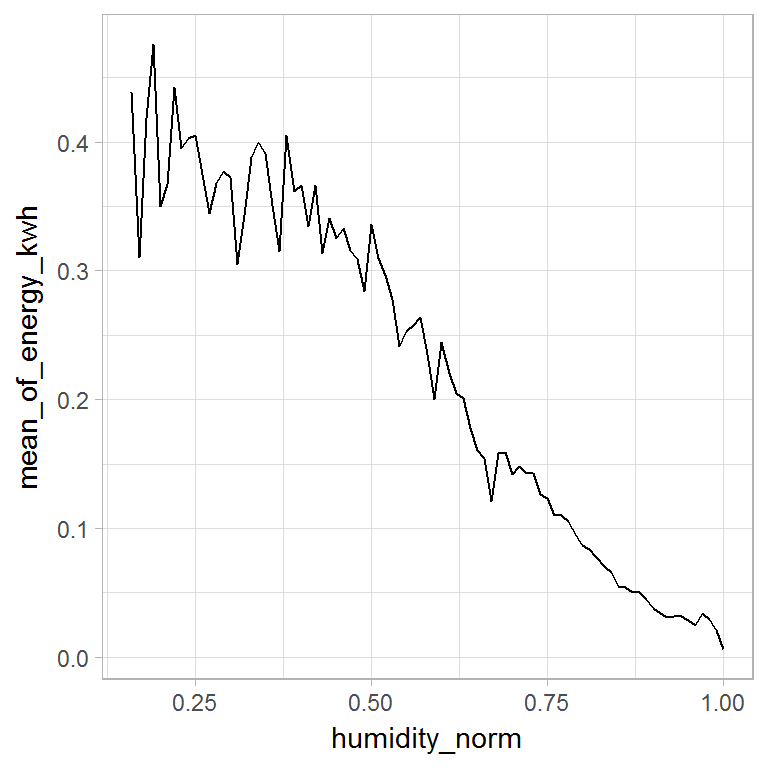

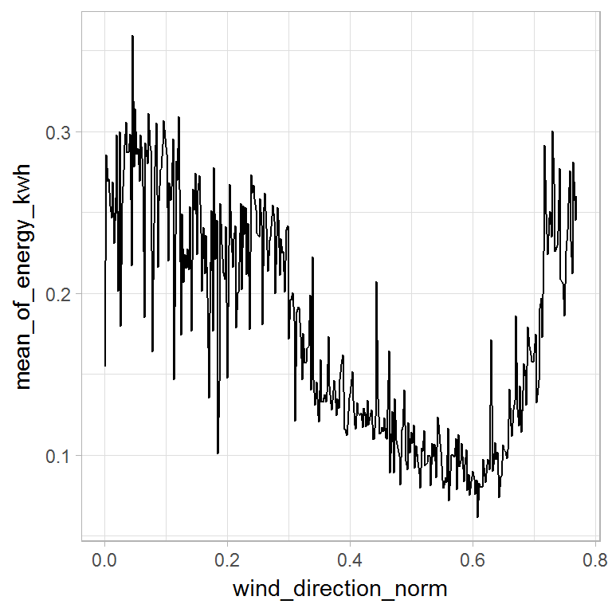

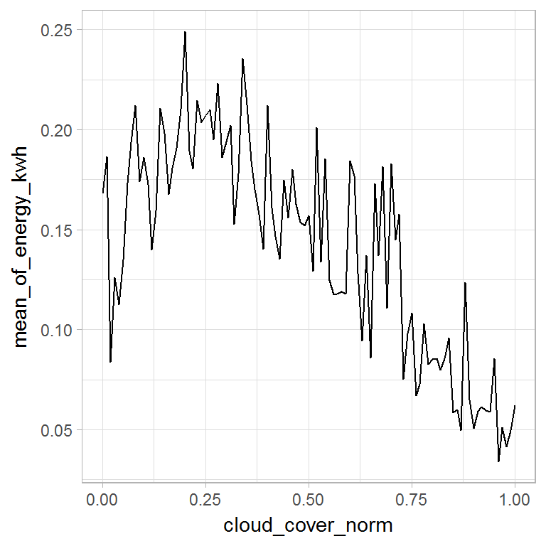

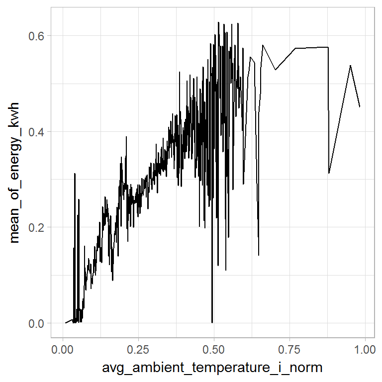

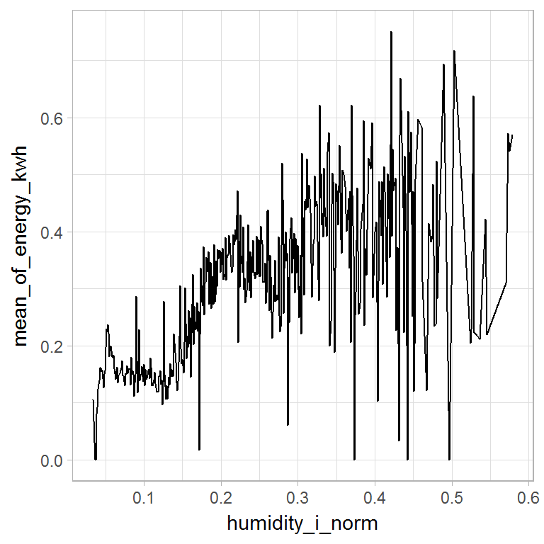

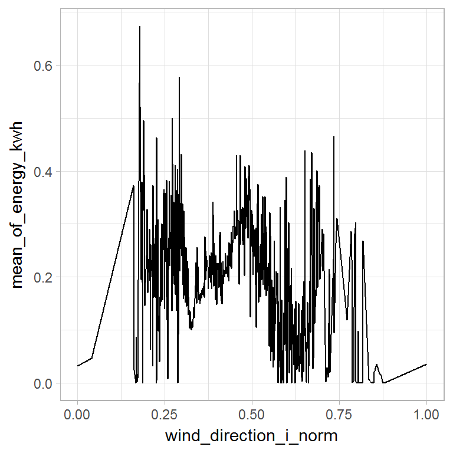

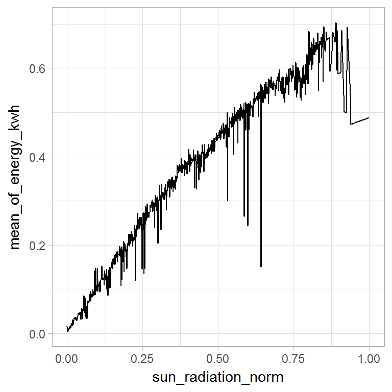

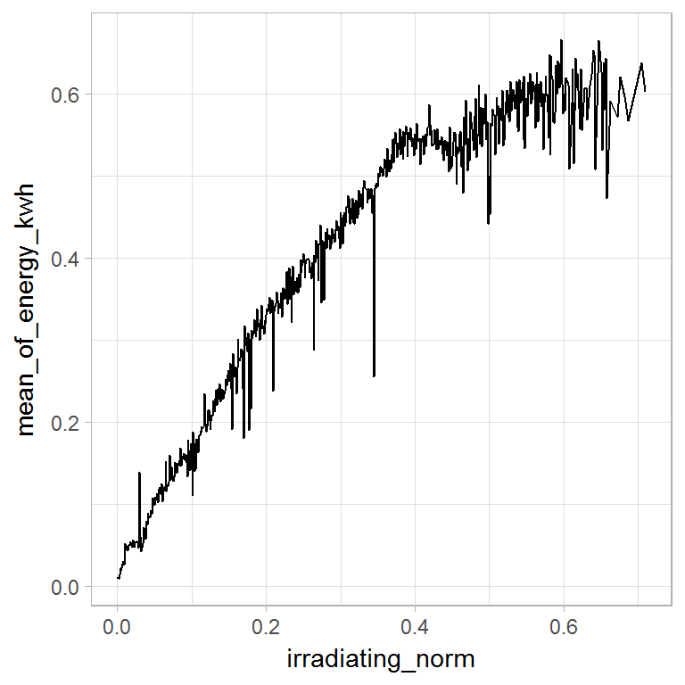

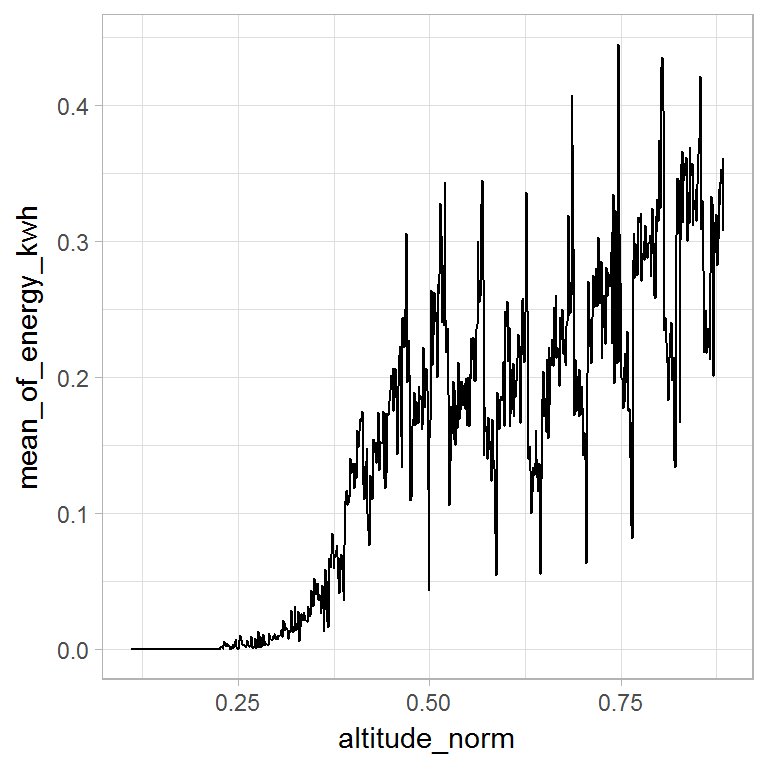

[4 more figures not shown]

## 11. Zmiana wytwarzanej energii w czasie i przestrzeni

W tym roździale prezentowany jest animowany wykres obrazujący wytwarzaną energię w czasie i przestrzeni. Każda kolejna klatka przezentuje wytwarzaną energię w danym miesiącu, osie x i y odpowiadają współrzędnym, użyty kolor zależy od lokalizacji elektrowni, natomiast wielkość punktów jest zależna od sumy wytwarzanej energii w danym miesiącu. W razie problemów proszę skorzystać z przeglądarki Google Chrome.

[video not shown]

## 12. Tworzenie regresora oraz analiza modelu regresji

W tej sekcji tworzony jest regresor, który ma za zadanie przewidzieć energię wytwarzaną przez elektrownie słoneczną.

Jako dane uczące zostały użyte rekordy z roku 2012, a jako dane testowe - dane z 2013, pozawala to na lepsze nauczenie regresora dla danych z całego roku, jednocześnie zachowując zasadę ciągłości danych. W trakcie całego roku atrybuty przyjmują bardzo zróżnicowane wartości np. w zimie jest mało słońca więc mało energii, w lecie odwrotnie.

Do nauki regresora użyty został algorytm Random Forest. Algorytm ten mimo dużej ilości atrybutów i ogromnej porcji danych uczy się w akceptowalnym czasie, jednocześnie zapewniając dobrą jakość regresji. Jest on również odporny na szumy i wartości odstające.

Podczas tworzenia regresora pominięto następujące atrybuty:

- id - gdyż jest to identyfikator rekordu nieprzydatny do tworzenia regresora
- id_location - jego funkcję spełniają latitude_norm oraz longitude_norm
- year - nieprzydatne ze wzlgędu na podział zbioru
- pcnm_norm_X - ze względu na bardzo niskie skorelowanie - nie mają istotnego wpływu na wynik, a ich pominięcie wpływa pozytywnie na szybkość przetwarzania
- date_time oraz date_posix - są nieznormalizowane, poza tym ich funkcję pełnią day_of_year_norm oraz hour_of_day_norm
- longitude_for_animated_plot oraz latitude_for_animated_plot - zostały stworzone tylko na potrzeby wykresu animowanego z rozdziału 11

#### Wynik regresji na danych testowych

Poniżej prezentowany jest wykres na którym możemy zobaczyć różnice w wielkościach faktycznie wytwarzanej energii oraz przewidzianej przez regresor.

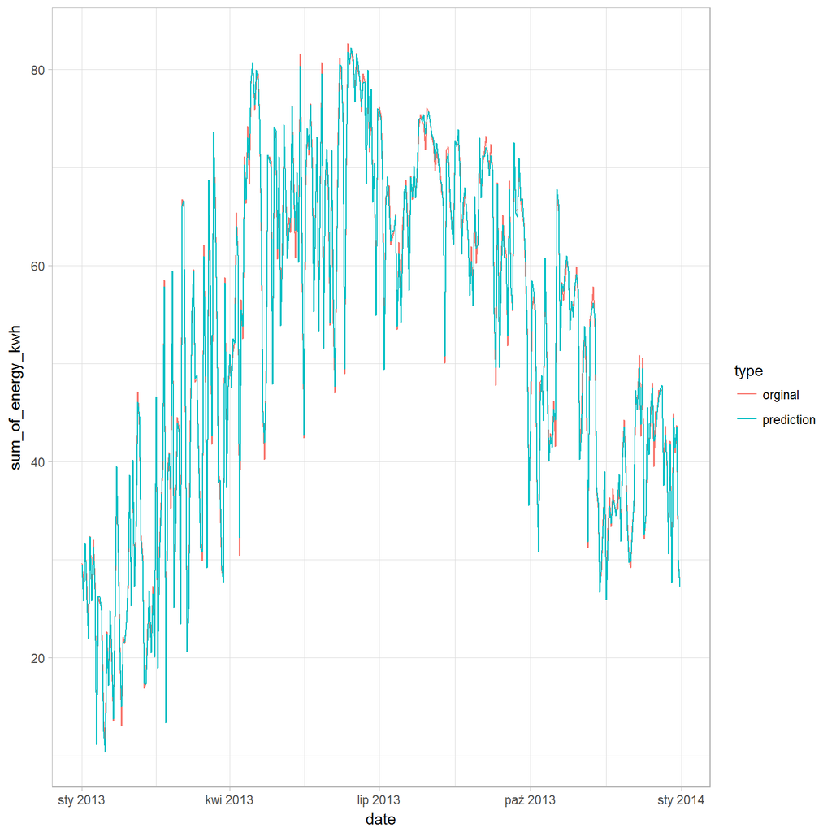

#### Parametry oceny regresji

Wartość parametru RMSE:

```
## [1] 0.1202339
```

Wartość parametru Rsquared:

```
## [1] 0.7148644
```

Wartość parametru MAE:

```
## [1] 0.06595733
```

#### Wykresy ważności atrybutów wykorzystanych w predykcji

Poniżej zaprezentowane zostały wykresy ważności atrybutów wykorzystanych w predykcji. Najważniejszymi atrybutami są azimuth_norm, sun_radiation_norm oraz day_of_year_norm. Istotny wpływ na działanie klasyfikatora miały również atrybuty wind_speed_norm, altitude_norm oraz age_in_months_norm.

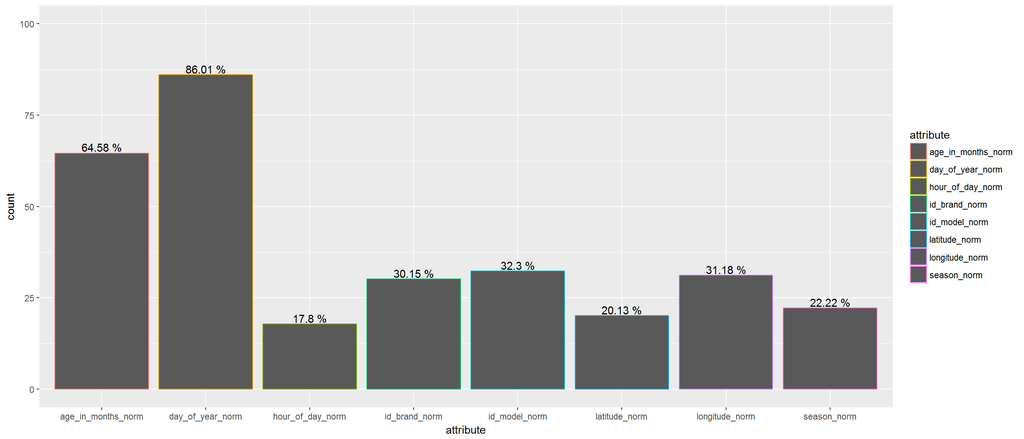

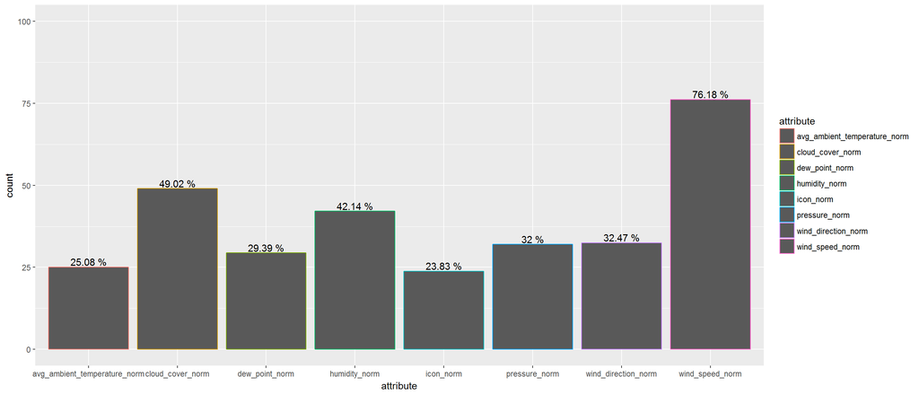

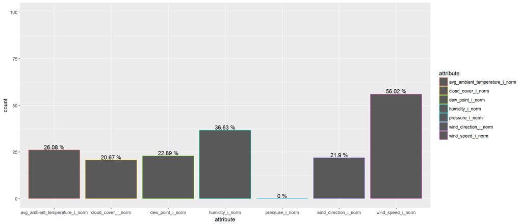

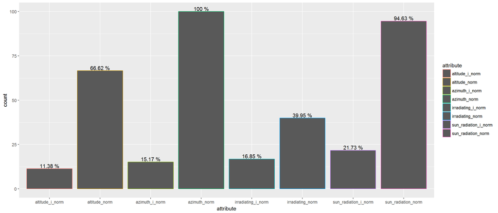